# P P1. Regresión

Objetivo del proyecto:

El objetivo principal es predecir la longitud total de los tlacuaches (totlngth) a partir de variables morfométricas y demográficas, como edad, sexo, tamaño de cola, sitio de captura, entre otras. Se busca identificar cuáles de estas variables tienen mayor poder predictivo y caracterizar la relación entre ellas y la longitud total, utilizando modelos de regresión lineal y no lineal. Esto permitirá entender mejor los factores que influyen en el tamaño de los tlacuaches y evaluar la capacidad de los modelos para realizar predicciones precisas y generalizables.

Datos obtenidos de https://www.kaggle.com/datasets/abrambeyer/openintro-possum

- case: caso de observación
- site: El sitio donde el tlacuache fue atrapado.
- Pop: Población, Vic (Victoria) o other (New South Wales o Queensland).
- sex: m (macho) o f (hembra).
- age: Edad.
- hdlngth: Longitud de cabeza en mm.
- skullw: Ancho de cráneo en mm.
- totlngth: Longitud total en cm (variable respuesta de interés).
- taill: Tamaño de cola en cm.
- footlgth: Longitud de pies en mm.
- earconch: Longitud de caracola de la oreja en mm.
- eye: Distancia del canto medial al canto lateral del ojo derecho en mm.
- chest: Circunferencia del pecho en cm.
- belly: Circunferencia del vientre en cm.

Fuente de los datos:

Los datos fueron descargados de [Kaggle: OpenIntro Possum Dataset](https://www.kaggle.com/datasets/abrambeyer/openintro-possum).

```
Cantidad de observaciones: 104
Cantidad de variables: 14

Nombres de las variables:
['case', 'site', 'Pop', 'sex', 'age', 'hdlngth', 'skullw', 'totlngth', 'taill', 'footlgth', 'earconch', 'eye', 'chest', 'belly']

Tipos de variables:
case          int64
site          int64
Pop          object
sex          object
age         float64
hdlngth     float64
skullw      float64
totlngth    float64
taill       float64
footlgth    float64
earconch    float64
eye         float64
chest       float64
belly       float64
dtype: object

Primeras filas del dataframe:
   case  site  Pop sex  age  hdlngth  skullw  totlngth  taill  footlgth  \
0     1     1  Vic   m  8.0     94.1    60.4      89.0   36.0      74.5
1     2     1  Vic   f  6.0     92.5    57.6      91.5   36.5      72.5
2     3     1  Vic   f  6.0     94.0    60.0      95.5   39.0      75.4
3     4     1  Vic   f  6.0     93.2    57.1      92.0   38.0      76.1
4     5     1  Vic   f  2.0     91.5    56.3      85.5   36.0      71.0

   earconch   eye  chest  belly
0      54.5  15.2   28.0   36.0
1      51.2  16.0   28.5   33.0
2      51.9  15.5   30.0   34.0
3      52.2  15.2   28.0   34.0
4      53.2  15.1   28.5   33.0

Resumen estadístico de las variables numéricas:
             case        site         age     hdlngth      skullw    totlngth  \
count  104.000000  104.000000  102.000000  104.000000  104.000000  104.000000
mean    52.500000    3.625000    3.833333   92.602885   56.883654   87.088462
std     30.166206    2.349086    1.909244    3.573349    3.113426    4.310549
min      1.000000    1.000000    1.000000   82.500000   50.000000   75.000000
25%     26.750000    1.000000    2.250000   90.675000   54.975000   84.000000
50%     52.500000    3.000000    3.000000   92.800000   56.350000   88.000000
75%     78.250000    6.000000    5.000000   94.725000   58.100000   90.000000
max    104.000000    7.000000    9.000000  103.100000   68.600000   96.500000

            taill    footlgth    earconch         eye       chest       belly
count  104.000000  103.000000  104.000000  104.000000  104.000000  104.000000
mean    37.009615   68.459223   48.130769   15.046154   27.000000   32.586538
std      1.959518    4.395306    4.109380    1.050374    2.045597    2.761949
min     32.000000   60.300000   40.300000   12.800000   22.000000   25.000000
25%     35.875000   64.600000   44.800000   14.400000   25.500000   31.000000
50%     37.000000   68.000000   46.800000   14.900000   27.000000   32.500000
75%     38.000000   72.500000   52.000000   15.725000   28.000000   34.125000
max     43.000000   77.900000   56.200000   17.800000   32.000000   40.000000
```

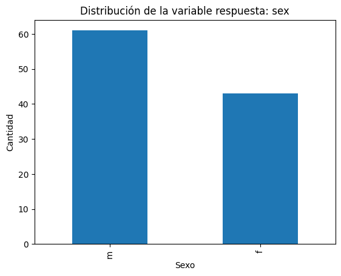

```python
import pandas as pd

df = pd.read_csv('possum.csv')

# Cantidad de observaciones y variables
print("Cantidad de observaciones:", df.shape[0])
print("Cantidad de variables:", df.shape[1])

# Nombres de las variables
print("\nNombres de las variables:")
print(df.columns.tolist())

# Tipos de variables
print("\nTipos de variables:")
print(df.dtypes)

# Primeras filas del dataframe
print("\nPrimeras filas del dataframe:")
print(df.head())

# Resumen estadístico de las variables numéricas
print("\nResumen estadístico de las variables numéricas:")
print(df.describe())

# Distribución de la variable respuesta de interés (sex)
import matplotlib.pyplot as plt

df['sex'].value_counts().plot(kind='bar')
plt.title('Distribución de la variable respuesta: sex')
plt.xlabel('Sexo')
plt.ylabel('Cantidad')
plt.show()
```

```python
df['male'] = df['sex'].map({'f': 0, 'm': 1})
df = df.drop(columns=['sex'])


df['Vic'] = df['Pop'].map({'Vic': 1, 'other': 0})
df = df.drop(columns=['Pop'])
```

Verificamos que ya no haya datos faltantes

```python
# Checamos huecos en los datos
df.isnull().sum()
# Eliminamos las filas con datos faltantes ya que son pocos
df = df.dropna()
```

Verificamos la colinealidad entre variables predictoras usando un mapa de calor de la matriz de correlación para identificar posibles problemas de multicolinealidad.

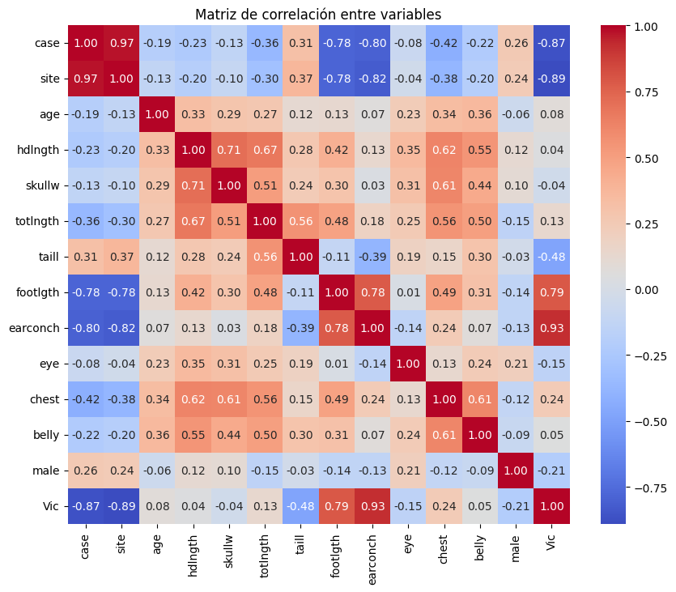

```python
import seaborn as sns
plt.figure(figsize=(10, 8))
sns.heatmap(df.corr(), annot=True, fmt=".2f", cmap='coolwarm')
plt.title('Matriz de correlación entre variables')
plt.show()
df = df.drop(columns=['case', 'Vic'])
```

La alta colinealidad entre site y vic nos sugiere eliminar dos de las tres variables:

- Eliminaremos case ya que es un identificador único y no aporta información predictiva.
- Eliminaremos Vic ya que site aporta más información.

La metodología de selección hacia atrás fue elegida porque tenemos una cantidad alta de variables y buscamos eliminar las que no aportan al modelo, optimizando la predicción del modelo. Este método es útil cuando se sospecha que algunas variables pueden ser redundantes o no relevantes, permitiendo identificar el subconjunto más informativo.

```python
from sklearn.linear_model import LinearRegression
import numpy as np

def adjusted_r2_score(model, X, y):
    r2 = model.score(X, y)
    n = X.shape[0]
    p = X.shape[1]
    return 1 - (1 - r2) * (n - 1) / (n - p - 1)

features = list(X.columns)
current_X = X.copy()
best_adj_r2 = -np.inf
improvement = True

while improvement and len(features) > 1:
    scores = []
    for feature in features:
        temp_features = [f for f in features if f != feature]
        model = LinearRegression().fit(current_X[temp_features], y)
        adj_r2 = adjusted_r2_score(model, current_X[temp_features], y)
        scores.append((adj_r2, feature))
    scores.sort(reverse=True)
    best_score, feature_to_remove = scores[0]
    if best_score > best_adj_r2:
        best_adj_r2 = best_score
        features.remove(feature_to_remove)
        print(f"Atributo eliminado: {feature_to_remove}, R^2 ajustado: {best_score:.4f}")
    else:
        improvement = False

print("Características finales seleccionadas:", features)
```

```
Atributo eliminado: age, R^2 ajustado: 0.7498
Atributo eliminado: eye, R^2 ajustado: 0.7523
Atributo eliminado: skullw, R^2 ajustado: 0.7548
Atributo eliminado: belly, R^2 ajustado: 0.7570
Atributo eliminado: chest, R^2 ajustado: 0.7589
Atributo eliminado: earconch, R^2 ajustado: 0.7603
Características finales seleccionadas: ['site', 'hdlngth', 'taill', 'footlgth', 'male']
```

Solo las siguientes variables fueron seleccionadas tras el proceso de selección de características:

- site
- hdlngth
- taill
- footlgth
- male

Ajusté un modelo de regresión lineal con las variables seleccionadas, ya que la relación entre las variables predictoras y la respuesta es principalmente lineal según el análisis.

Entrené un modelo de regresión polinomial de grado 2 para verificar si una relación no lineal mejoraba el ajuste, comparando los valores de R2.

Un coeficiente es significativo si su valor absoluto es considerable y consistente con el contexto del problema, y si el modelo mejora al incluirlo. Por ejemplo, los coeficientes de (0.47) y (1.30) son relativamente altos, lo que indica una fuerte asociación positiva con la longitud total.

Para afirmar estadísticamente la significancia, sería necesario calcular los intervalos de confianza o los valores p, pero el proceso de selección y el tamaño de los coeficientes ya nos dan una buena indicación de su relevancia en el modelo.

```
Coeficientes del modelo lineal: [-0.71185787  0.47662833  1.30270388  0.07828891 -0.49589922]
Intercepto: -7.626044096800484
R^2 del modelo lineal (train): 0.7815101439455625
R^2 del modelo lineal (test): 0.6806403026653536
R^2 del modelo polinomial (grado 2, train): 0.8564164391677656
R^2 del modelo polinomial (grado 2, test): 0.5376934288333421
```

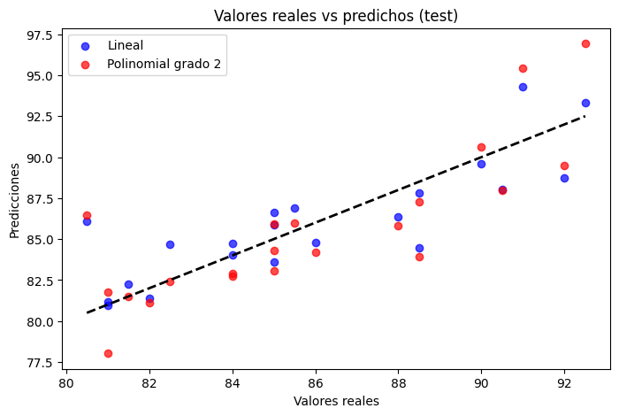

```python
from sklearn.model_selection import train_test_split
from sklearn.preprocessing import PolynomialFeatures
from sklearn.pipeline import Pipeline

df = df[features + ['totlngth']]

X = df.drop(columns=['totlngth'])
y = df['totlngth']

X_train, X_test, y_train, y_test = train_test_split(X, y, test_size=0.2, random_state=100)

# Entrenar modelo lineal con datos de entrenamiento
linear_model = LinearRegression()
linear_model.fit(X_train, y_train)
print("Coeficientes del modelo lineal:", linear_model.coef_)
print("Intercepto:", linear_model.intercept_)
print("R^2 del modelo lineal (train):", linear_model.score(X_train, y_train))
print("R^2 del modelo lineal (test):", linear_model.score(X_test, y_test))

# Modelo de regresión polinomial (grado 2)
poly_model = Pipeline([
    ('polynomialfeatures', PolynomialFeatures(degree=2, include_bias=False)),
    ('linearregression', LinearRegression())
])
poly_model.fit(X_train, y_train)
print("R^2 del modelo polinomial (grado 2, train):", poly_model.score(X_train, y_train))
print("R^2 del modelo polinomial (grado 2, test):", poly_model.score(X_test, y_test))

# Graficar valores reales vs predichos en el set de prueba para ambos modelos
y_test_pred_linear = linear_model.predict(X_test)
y_test_pred_poly = poly_model.predict(X_test)

plt.figure(figsize=(8, 5))
plt.scatter(y_test, y_test_pred_linear, label='Lineal', color='blue', alpha=0.7)
plt.scatter(y_test, y_test_pred_poly, label='Polinomial grado 2', color='red', alpha=0.7)
plt.plot([y_test.min(), y_test.max()], [y_test.min(), y_test.max()], 'k--', lw=2)
plt.xlabel('Valores reales')
plt.ylabel('Predicciones')
plt.title('Valores reales vs predichos (test)')
plt.legend()
plt.show()
```

Interpretación de las métricas

```python
from sklearn.metrics import mean_squared_error, r2_score

# Calculamos el error cuadrático medio (MSE) en el set de prueba
mse = mean_squared_error(y_test, y_test_pred_linear)
mse_train = mean_squared_error(y_train, linear_model.predict(X_train))
print("Error cuadrático medio (MSE) en test:", mse)
print("Error cuadrático medio (MSE) en train:", mse_train)

# Calculamos el coeficiente de determinación R^2 en el set de prueba
r2 = r2_score(y_test, y_test_pred_linear)
r2_train = r2_score(y_train, linear_model.predict(X_train))
print("Coeficiente de determinación R^2 en test:", r2)
print("Coeficiente de determinación R^2 en train:", r2_train)

# Modelo polinomial
mse_poly = mean_squared_error(y_test, y_test_pred_poly)
mse_poly_train = mean_squared_error(y_train, poly_model.predict(X_train))
r2_poly = r2_score(y_test, y_test_pred_poly)
r2_poly_train = r2_score(y_train, poly_model.predict(X_train))
print("Error cuadrático medio (MSE) en test (polinomial):", mse_poly)
print("Error cuadrático medio (MSE) en train (polinomial):", mse_poly_train)
print("Coeficiente de determinación R^2 en test (polinomial):", r2_poly)
print("Coeficiente de determinación R^2 en train (polinomial):", r2_poly_train)
```

[output not shown]

El coeficiente de 'hdlngth' está entre 0.321 y 0.632 con un 95% de confianza, lo que indica que, manteniendo constantes las demás variables, un aumento de 1 mm en la longitud de la cabeza se asocia con un incremento estimado de entre 0.32 y 0.63 cm en la longitud total del tlacuache.

Además, la longitud total promedio estimada para un tlacuache con valores promedio en las variables predictoras es de 87.63 cm, con un intervalo de confianza del 95% entre 87.17 y 88.08 cm.

```python
import statsmodels.api as sm

# Usamos las variables seleccionadas para inferencia
X_infer = X_train.copy()
X_infer = sm.add_constant(X_infer)  # Agrega el intercepto
y_infer = y_train

# Ajustar el modelo de regresión lineal con statsmodels
model_infer = sm.OLS(y_infer, X_infer).fit()

# Resumen del modelo con intervalos de confianza
print(model_infer.summary())

# Inferencia para intervalo de confianza para el coeficiente de 'hdlngth'
conf_int = model_infer.conf_int().loc['hdlngth']
print(f"\nEl coeficiente de 'hdlngth' está entre {conf_int[0]:.3f} y {conf_int[1]:.3f} con 95% de confianza.")

# Inferencia sobre la media de la respuesta para una observación promedio
mean_pred = model_infer.get_prediction(X_infer.mean().to_frame().T)
mean_ci = mean_pred.conf_int()[0]
print(f"\nLa longitud total promedio estimada es {mean_pred.predicted_mean[0]:.2f} cm, con un intervalo de confianza del 95% entre {mean_ci[0]:.2f} y {mean_ci[1]:.2f}.")
```

```
                            OLS Regression Results
==============================================================================
Dep. Variable:               totlngth   R-squared:                       0.782
Model:                            OLS   Adj. R-squared:                  0.767
Method:                 Least Squares   F-statistic:                     52.94
Date:                Mon, 08 Sep 2025   Prob (F-statistic):           4.50e-23
Time:                        00:00:54   Log-Likelihood:                -167.62
No. Observations:                  80   AIC:                             347.2
Df Residuals:                      74   BIC:                             361.5
Df Model:                           5
Covariance Type:            nonrobust
==============================================================================
                 coef    std err          t      P>|t|      [0.025      0.975]
------------------------------------------------------------------------------
const         -7.6260      7.507     -1.016      0.313     -22.584       7.332
site          -0.7119      0.187     -3.804      0.000      -1.085      -0.339
hdlngth        0.4766      0.078      6.097      0.000       0.321       0.632
taill          1.3027      0.142      9.156      0.000       1.019       1.586
footlgth       0.0783      0.095      0.824      0.413      -0.111       0.268
male          -0.4959      0.494     -1.003      0.319      -1.481       0.489
==============================================================================
Omnibus:                        5.499   Durbin-Watson:                   1.974
Prob(Omnibus):                  0.064   Jarque-Bera (JB):                4.767
Skew:                          -0.565   Prob(JB):                       0.0922
Kurtosis:                       3.392   Cond. No.                     3.98e+03
==============================================================================

Notes:
[1] Standard Errors assume that the covariance matrix of the errors is correctly specified.
[2] The condition number is large, 3.98e+03. This might indicate that there are
strong multicollinearity or other numerical problems.

El coeficiente de 'hdlngth' está entre 0.321 y 0.632 con 95% de confianza.

La longitud total promedio estimada es 87.63 cm, con un intervalo de confianza del 95% entre 87.17 y 88.08.
```